# Data Wrangling with dplyr

```r
#Put all necessary libraries here

library(ggplot2)
library(readr)
library(dplyr)
library(ggthemes)
```

**We will use a few datasets:** * We will use the data on all reported crashes in Delaware County for 2016. Information regarding the various variables can be found at this [link](https://data.pa.gov/Public-Safety/Crash-Data-1997-to-Current-Transportation/dc5b-gebx). * We will also use data from [this municipality website](http://munstats.pa.gov/Reports/ReportInformation2.aspx?report=CountyMuniDemo_Excel) which provides some demographic information on the counties. * Lastly, we will look at chronic illness data from the [CDC](https://catalog.data.gov/dataset/u-s-chronic-disease-indicators-cdi-e50c9).

```r
#Load the crash dataset
crash_del <- read_csv("~/DataScience/Statistics/Data/crash_del.csv")

#Additional demographic information dataset
CountyMuniDemo <- read_csv("~/DataScience/Statistics/Data/CountyMuniDemo.csv")

#CDC data
CDC <- read_csv("~/DataScience/Statistics/Data/CDC2.csv")
```

Let’s create a dataframe that lists the number of accidents involving bicycles by municipality where the table is sorted by the number of accidents, from the most to the least. Which municipality had the most bicycle accidents?

```r
crash_del_df <- crash_del %>%
  filter(Bicycle == "Yes") %>%
  select(Municipality.Name, Bicycle) %>%
  group_by(Municipality.Name) %>%
  summarise(Number_Accidents = n()) %>%
  arrange(desc(Number_Accidents))

crash_del_df
```

```
## # A tibble: 17 x 2
##    Municipality.Name    Number_Accidents
##    <chr>                           <int>
##  1 Upper Darby Twp                    10
##  2 Chester City                        7
##  3 Haverford Twp                       4
##  4 Radnor Twp                          3
##  5 Chadds Ford Twp                     2
##  6 Collingdale Boro                    2
##  7 Darby Boro                          2
##  8 Morton Boro                         2
##  9 Ridley Twp                          2
## 10 Sharon Hill Boro                    2
## 11 Springfield Twp                     2
## 12 Swarthmore Boro                     2
## 13 Brookhaven Boro                     1
## 14 Lower Chichester Twp                1
## 15 Thornbury Twp                       1
## 16 Tinicum Twp                         1
## 17 Upper Chichester Twp                1
```

Upper Darby Township has the most number of accidents related to bicycle (10).

Notice that the columns associated with road work have a lot of NAs. Let’s determine the number of NAs for each column that is associated with road work.

```r
road_work_cols <- crash_del %>%
  select(contains("Work.Zone")) %>%
  summarise_all(funs(sum(is.na(.))))

road_work_cols
```

```
## # A tibble: 1 x 10
##   Work.Zone.Type Work.Zone.Location Work.Zone.Close.Deto… Work.Zone.Flagg…
##            <int>              <int>                 <int>            <int>
## 1           4987               4985                  5001             4994
## # ... with 6 more variables: Work.Zone.Law.Officer <int>,
## #   Work.Zone.Closure <int>, Work.Zone.Moving <int>,
## #   Work.Zone.Other <int>, Work.Zone.Shoulder.Median <int>,
## #   Work.Zone <int>
```

Let’s create a dataset that records the following: When a road worker is present when the accident occurred, break down by collision type, the frequency of the collision, the mean number of injuries, and the max number of injuries.

```r
crash_del_rwp <- crash_del %>%
  filter(Workers.Present == "Y") %>%
  select(Collision.Type, Injury.Count) %>%
  group_by(Collision_Type = Collision.Type) %>%
  summarise(Frequency_Collisions = n(), Mean_Num_Injuries = mean(Injury.Count), Max_Num_Injury = max(Injury.Count))

crash_del_rwp
```

```
## # A tibble: 4 x 4
##   Collision_Type   Frequency_Collisions Mean_Num_Injuries Max_Num_Injury
##   <chr>                           <int>             <dbl>          <dbl>
## 1 Angle                               3             0.667              1
## 2 Hit fixed object                    4             0.75               2
## 3 Hit pedestrian                      4             1.5                3
## 4 Rear-end                            3             1.67               5
```

‘Hitting pedestrian’ and ‘Rear-end collision’ caused more number of injuries on average (1.5 and 1.67 respectively) and the max number of injuries during these collision types was significantly more (3 and 5 resp.) than when the collision type was ‘Angle’ or ‘Hit fixed object’.

Let’s look at the relationship between the variables `Overturned` and `Speeding`.

Let’s create a dataset that gives the counts for each category (e.g., when Overturned = Yes and Speeding = No), and the conditional proportions of speeding or not speeding, given a car was overturned or not.

```r
crash_del_speed <- crash_del %>%
  select(Overturned, Speeding) %>%
  group_by(Overturned, Speeding) %>%
  summarise(Count = n()) %>%
  mutate(Cond_Prop = Count / sum(Count))

crash_del_speed
```

```
## # A tibble: 4 x 4
## # Groups:   Overturned [2]
##   Overturned Speeding Count Cond_Prop
##   <chr>      <chr>    <int>     <dbl>
## 1 No         No        4777    0.974
## 2 No         Yes        127    0.0259
## 3 Yes        No          94    0.913
## 4 Yes        Yes          9    0.0874
```

Now, let’s create a dataset that gives the counts and the other conditional proportions (given there was speeding or not, the proportion of times a car was overturned and the proportion of times a car wasn’t overturned).

```r
crash_del_speed2 <- crash_del %>%
  select(Speeding, Overturned) %>%
  group_by(Speeding, Overturned) %>%
  summarise(Count = n()) %>%
  mutate(Cond_Prop = Count / sum(Count))

crash_del_speed2
```

```
## # A tibble: 4 x 4
## # Groups:   Speeding [2]
##   Speeding Overturned Count Cond_Prop
##   <chr>    <chr>      <int>     <dbl>
## 1 No       No          4777    0.981
## 2 No       Yes           94    0.0193
## 3 Yes      No           127    0.934
## 4 Yes      Yes            9    0.0662
```

Notice how the ordering of the `group_by` impacted the `mutate`: The first element of ‘group_by’ appeared as the first column and the second element as the second column. Depending on whether it evaluated to “Yes” or “No”, the mutate function added a column which basically gave the conditional probability of second column (second element of ‘group_by’) occuring given that the first column (first element of ‘group_by’) occured.

Let’s see if there is a relationship between the population size of the county and the number of reported accidents.

Let’s create a dataset which has the number of reported accidents by municipality and add the demographic information from the additional dataset.

```r
crash_all <- crash_del %>%
  group_by(Muni_Name = tolower(Municipality.Name)) %>%
  summarise(Number_Accidents = n())

demo <- CountyMuniDemo
demo$MUNICIPALITY_NAME <- tolower(demo$MUNICIPALITY_NAME)

demo2 <- select(demo, MUNICIPALITY_NAME, CENSUS_POPULATION)

crash_demo <- left_join(crash_all, demo2, by = c("Muni_Name"= "MUNICIPALITY_NAME"))
crash_demo
```

```
## # A tibble: 47 x 3
##    Muni_Name            Number_Accidents CENSUS_POPULATION
##    <chr>                           <int>             <int>
##  1 aldan boro                         43              4152
##  2 aston twp                         105             16592
##  3 bethel twp                         48              8791
##  4 brookhaven boro                    54              8006
##  5 chadds ford twp                   106              3640
##  6 chester city                      448             33972
##  7 chester heights boro               46              2531
##  8 chester twp                        59              3940
##  9 clifton heights boro               34              6652
## 10 collingdale boro                   66              8786
## # ... with 37 more rows
```

We used left_join() above. Three municipalities were dropped- colwyn boro, delaware county, east lansdowne boro.

Let’s create a graphic comparing the population and number of reported accidents.

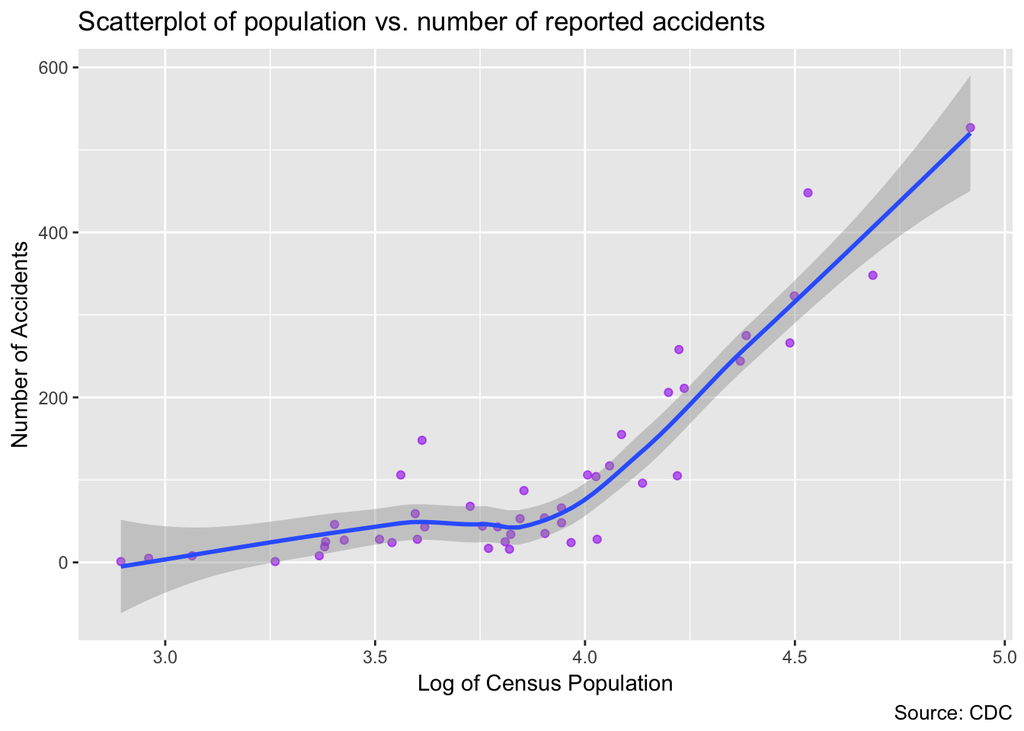

```r
ggplot(crash_demo, aes(x = log10(CENSUS_POPULATION), y = Number_Accidents)) +
  geom_point(col = "purple",
             alpha = 0.6) +
  geom_smooth() +
  labs(x = "Log of Census Population",
       y = "Number of Accidents",
       title = "Scatterplot of population vs. number of reported accidents",
       caption = "Source: CDC")
```

The average number of reported accidents for counties with population upto 10,000 is approx. 50. However, the number of reported accidents increase significantly more wrt to population for counties with population over 10,000. For population of about 32,000, there are approx. 300 reported accidents. Looking at the trend of number of accidents for population up to 10,000, we would expect this figure to be about 150, however it is twice as much.

**For the rest of the analysis, let’s use the CDC data.**

```r
CDC3 <- select(CDC, YearStart, Topic) %>%
  filter(YearStart == '2016') %>%
  group_by(Topic) %>%
  summarise(Num_Obs = n())
CDC3
```

```
## # A tibble: 16 x 2
##    Topic                                           Num_Obs
##    <chr>                                             <int>
##  1 Alcohol                                             550
##  2 Arthritis                                           660
##  3 Asthma                                              605
##  4 Cancer                                              385
##  5 Cardiovascular Disease                              440
##  6 Chronic Kidney Disease                              110
##  7 Chronic Obstructive Pulmonary Disease               876
##  8 Diabetes                                           1257
##  9 Immunization                                        110
## 10 Mental Health                                       165
## 11 Nutrition, Physical Activity, and Weight Status     604
## 12 Older Adults                                        220
## 13 Oral Health                                         440
## 14 Overarching Conditions                              660
## 15 Reproductive Health                                  55
## 16 Tobacco                                             605
```

There are 16 distinct topics for 2016.

Let’s study influenza vaccination patterns since the flu has been so bad this year!

```r
CDC4 <- select(CDC, YearStart, LocationAbbr, Question, DataValueType, DataValue) %>%
  filter(LocationAbbr == "US" | LocationAbbr == "PA",
         Question == "Influenza vaccination among noninstitutionalized adults aged >= 18 years",
         DataValueType == "Age-adjusted Prevalence")
CDC4
```

```
## # A tibble: 12 x 5
##    YearStart LocationAbbr Question               DataValueType   DataValue
##        <int> <chr>        <chr>                  <chr>               <dbl>
##  1      2016 US           Influenza vaccination… Age-adjusted P…      38
##  2      2016 PA           Influenza vaccination… Age-adjusted P…      40.4
##  3      2015 PA           Influenza vaccination… Age-adjusted P…      41.3
##  4      2015 US           Influenza vaccination… Age-adjusted P…      40.9
##  5      2012 PA           Influenza vaccination… Age-adjusted P…      35.3
##  6      2012 US           Influenza vaccination… Age-adjusted P…      37
##  7      2011 PA           Influenza vaccination… Age-adjusted P…      36.5
##  8      2011 US           Influenza vaccination… Age-adjusted P…      38.1
##  9      2014 PA           Influenza vaccination… Age-adjusted P…      37.7
## 10      2014 US           Influenza vaccination… Age-adjusted P…      39.4
## 11      2013 PA           Influenza vaccination… Age-adjusted P…      37.3
## 12      2013 US           Influenza vaccination… Age-adjusted P…      38.8
```

Let’s create a line graph comparing the immunization rates of Pennsylvania and the US.

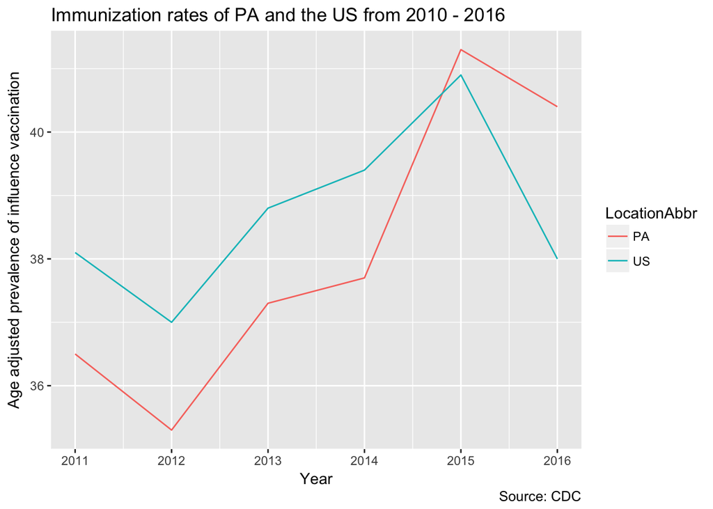

```r
ggplot(CDC4, aes(x = YearStart, y = DataValue, col = LocationAbbr)) +
  geom_line() +
  labs(title = "Immunization rates of PA and the US from 2010 - 2016",
       x = "Year",
       y = "Age adjusted prevalence of influence vaccination",
          caption = "Source: CDC")
```

Let’s see how immunization rates vary by region of the country.

Join the following dataset to our CDC dataset so that we have a column signifying the region of the country.

```r
#We will use the following data to get the regions
USregions <- read_csv("~/DataScience/Statistics/Data/USregions.csv")
CDC_reg<- left_join(CDC, USregions, by = c("LocationDesc" = "State"))
CDC_reg
```

```
## # A tibble: 74,811 x 35
##    YearStart YearEnd LocationAbbr LocationDesc  DataSource Topic Question
##        <int>   <int> <chr>        <chr>         <chr>      <chr> <chr>
##  1      2016    2016 US           United States BRFSS      Alco… Binge dr…
##  2      2016    2016 AL           Alabama       BRFSS      Alco… Binge dr…
##  3      2016    2016 AK           Alaska        BRFSS      Alco… Binge dr…
##  4      2016    2016 AZ           Arizona       BRFSS      Alco… Binge dr…
##  5      2016    2016 AR           Arkansas      BRFSS      Alco… Binge dr…
##  6      2016    2016 CA           California    BRFSS      Alco… Binge dr…
##  7      2016    2016 CO           Colorado      BRFSS      Alco… Binge dr…
##  8      2016    2016 CT           Connecticut   BRFSS      Alco… Binge dr…
##  9      2016    2016 DE           Delaware      BRFSS      Alco… Binge dr…
## 10      2016    2016 DC           District of … BRFSS      Alco… Binge dr…
## # ... with 74,801 more rows, and 28 more variables: Response <chr>,
## #   DataValueUnit <chr>, DataValueType <chr>, DataValue <dbl>,
## #   DataValueAlt <dbl>, DataValueFootnoteSymbol <chr>,
## #   DatavalueFootnote <chr>, LowConfidenceLimit <dbl>,
## #   HighConfidenceLimit <dbl>, StratificationCategory1 <chr>,
## #   Stratification1 <chr>, StratificationCategory2 <chr>,
## #   Stratification2 <chr>, StratificationCategory3 <chr>,
## #   Stratification3 <chr>, GeoLocation <chr>, ResponseID <chr>,
## #   LocationID <chr>, TopicID <chr>, QuestionID <chr>,
## #   DataValueTypeID <chr>, StratificationCategoryID1 <chr>,
## #   StratificationID1 <chr>, StratificationCategoryID2 <chr>,
## #   StratificationID2 <chr>, StratificationCategoryID3 <chr>,
## #   StratificationID3 <chr>, Region <chr>
```

Notice that there are NAs in the region column of the new dataset.

District of Columbia is not in the USregions dataset; however, LocationDesc column contains District of Columbia in its rows. When we joined the matching values from the USregions to CDC dataset, each row that contained District of Columbia will have NA under the Region column.

Let’s create a dataset that contains the age adjusted influenza immunization rates in 2016 for each state in the country and sort it by highest immunization to lowest. Which state has the highest immunization?

```r
CDC5 <- select(CDC_reg, YearStart, YearEnd, LocationAbbr, Region, Question, DataValueType, DataValue) %>%
  filter(YearStart == "2016",
         YearEnd == "2016",
         !LocationAbbr == "DC",
         !LocationAbbr == "GU",
         !LocationAbbr == "PR",
         !LocationAbbr == "VI",
         Question == "Influenza vaccination among noninstitutionalized adults aged >= 18 years",
         DataValueType == "Age-adjusted Prevalence") %>%
  arrange(desc(DataValue))

CDC5
```

```
## # A tibble: 51 x 7
##    YearStart YearEnd LocationAbbr Region Question  DataValueType DataValue
##        <int>   <int> <chr>        <chr>  <chr>     <chr>             <dbl>
##  1      2016    2016 SD           MW     Influenz… Age-adjusted…      47.2
##  2      2016    2016 RI           NE     Influenz… Age-adjusted…      45.1
##  3      2016    2016 IA           MW     Influenz… Age-adjusted…      45
##  4      2016    2016 NE           MW     Influenz… Age-adjusted…      43.4
##  5      2016    2016 NC           S      Influenz… Age-adjusted…      43
##  6      2016    2016 MN           MW     Influenz… Age-adjusted…      42.9
##  7      2016    2016 CO           W      Influenz… Age-adjusted…      42.3
##  8      2016    2016 MD           NE     Influenz… Age-adjusted…      42.1
##  9      2016    2016 VA           S      Influenz… Age-adjusted…      41.9
## 10      2016    2016 CT           NE     Influenz… Age-adjusted…      41.4
## # ... with 41 more rows
```

South Dakota has the highest immunization.

Let’s construct a graphic of the 2016 influenza immunization rates by region of the country.

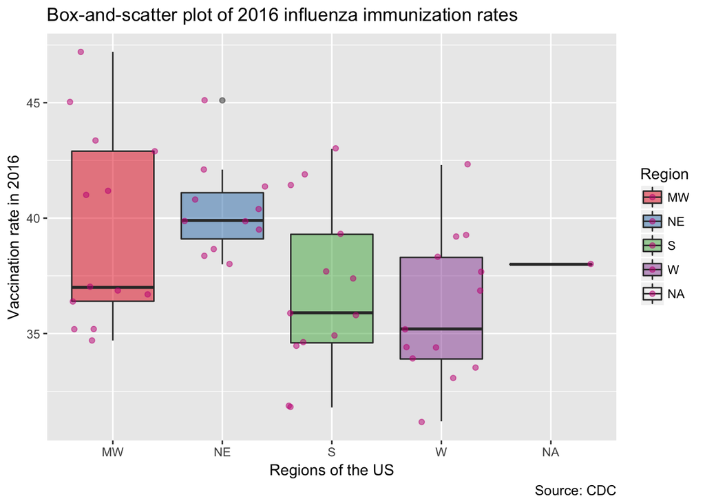

```r
ggplot(CDC5, aes( x= Region, y = DataValue, fill = Region)) +
  geom_boxplot(alpha = 0.5) +
  geom_jitter(col = "mediumvioletred",
              alpha =  0.5) +
  labs(x = "Regions of the US",
       y = "Vaccination rate in 2016",
       title = "Box-and-scatter plot of 2016 influenza immunization rates",
       caption = "Source: CDC") +
  scale_fill_brewer(palette="Set1")
```

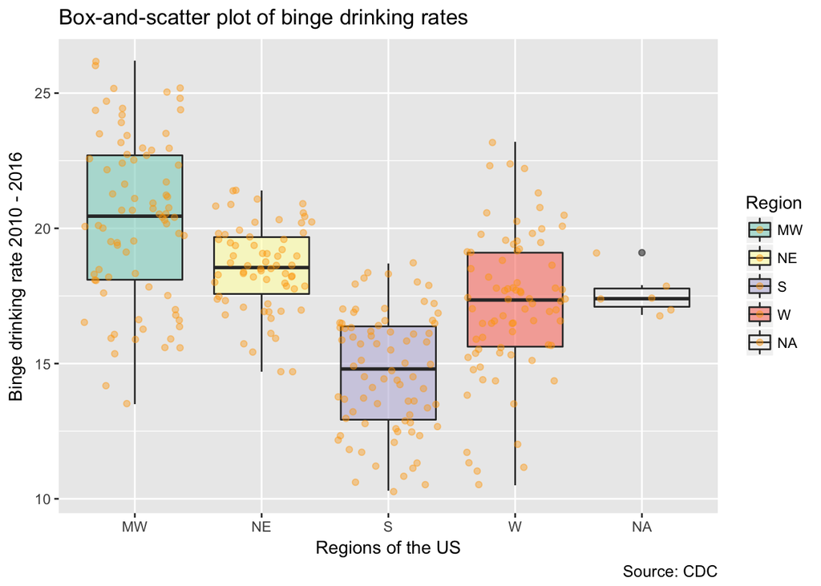

```r
explo <- select(CDC_reg, LocationAbbr, Region, Question, DataValueType, DataValue) %>%
  filter(!LocationAbbr == "DC",
         !LocationAbbr == "GU",
         !LocationAbbr == "PR",
         !LocationAbbr == "VI",
         Question == "Binge drinking prevalence among adults aged >= 18 years",
         DataValueType == "Age-adjusted Prevalence") %>%
  arrange(desc(DataValue))


ggplot(explo, aes( x= Region, y = DataValue, fill = Region)) +
  geom_boxplot(alpha = 0.6) +
  geom_jitter(col = "orange1",
              alpha =  0.4) +
  labs(x = "Regions of the US",
       y = "Binge drinking rate 2010 - 2016",
       title = "Box-and-scatter plot of binge drinking rates",
       caption = "Source: CDC") +
  scale_fill_brewer(palette="Set3")
```

From the graphic above, we can see that, as one would expect, on average the binge drinking rate among the states in the South is the lowest compared to other regions in the US. The binge drinking rate in the Midwest is the highest on average. Midwest has more states with higher rate of binge drinking among the population greater than 18 years old. Most of the states with rate lower than 15% are in the South and the West Coast whereas there are only 4 states in the Midwest and the Northeast where the binge drinking rate is lower than 15% among the adults greater than 18 years old.